# Chapter 8

P.102 カルマンフィルタリング ナイル川の流域データを使用

```r
#install.packages("cachem",dependencies = TRUE)
library(dlm)
y <- Nile
t_max <- length(y)
```

1時点分のカルマンフィルタリングを行う関数

```r
Kalman_filtering <- function(m_t_minus_1,C_t_minus_1,t){
  #一期先予測分布
  a_t <- G_t %*% m_t_minus_1
  R_t <- G_t %*% C_t_minus_1 %*% t(G_t) + W_t

  #一期先予測尤度
  f_t <- F_t %*% a_t
  Q_t <- F_t %*% R_t %*% t(F_t) +V_t

  #カルマンゲイン
  K_t <- R_t %*% t(F_t) %*% solve(Q_t)

  #状態の更新
  m_t <- a_t + K_t %*% (y[t]-f_t)
  C_t <- diag(nrow(R_t) - K_t %*% F_t) %*% R_t

  #フィルタリング分布と一期先予測分布の平均と分散を返す
  return(list(m = m_t, C= C_t,
              a = a_t, R = R_t))
}

#線形ガウス型状態空間のパラメータを設定（すべて1×1の行列）
G_t <- matrix(1, ncol=1, nrow=1); W_t <- matrix(exp(7.29), ncol=1, nrow=1)
F_t <- matrix(1, ncol=1, nrow=1); V_t <- matrix(exp(9.62), ncol=1,nrow=1)
m0 <- matrix(0,ncol=1,nrow=1); C0 <- matrix( 1e+7, ncol=1,nrow=1)

#フィルタリング分布（+一期先予測分布）の平均分散を求める
#状態ベクトルの初期化
m <- rep(NA_real_, t_max) ; C <- rep(NA_real_, t_max)
a <- rep(NA_real_, t_max) ; R <- rep(NA_real_, t_max)
```

時点：t-1

```r
KF <- Kalman_filtering(m0,C0,t = 1)
m[1] <- KF$m; C[1] <- KF$C
a[1] <- KF$a; R[1] <- KF$R
```

時点2～t_max

```r
for(t in 2:t_max){
  KF <- Kalman_filtering(m[t-1],C[t-1],t=t)
  m[t] <- KF$m; C[t] <- KF$C
  a[t] <- KF$a; R[t] <- KF$R
}
```

プロット。確かに平滑化できている。

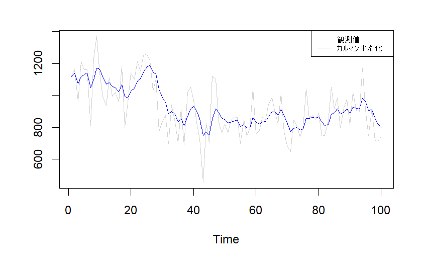

```r
y_plot <- as.vector(y)
ts.plot(cbind(y_plot,m),
        lty = c("solid","solid"),
        col = c("lightgray", "blue"),
        ylab = "")
#凡例
legend(legend = c("観測値","カルマン平滑化"),
       lty = c("solid","solid"),
       col = c("lightgray","blue"),
       x = "topright", text.width = 17, cex=0.6)
```

8.2 カルマン予測

予測期間

```r
t <- t_max
#予測期間は10期先まで
nAhead <- 10
```

K = 1期先カルマン予測を行う関数

```r
Kalman_prediction <- function(a_t0,R_t0){
  #一期先予測分布
  a_t1 <- G_t_plus_1 %*% a_t0
  R_t1 <- G_t_plus_1 %*% R_t0 %*% t(G_t_plus_1) + W_t_plus_1

  return(list(a=a_t1,R=R_t1))
}
```

線形ガウス型状態空間のパラメータを設定（時不変）

```r
G_t_plus_1 <- G_t; W_t_plus_1 <- W_t
```

k期先の予測分布の平均・分散を求める 状態の領域を確保

```r
a_ <- rep(NA_real_, t_max + nAhead); R_ <- rep(NA_real_, t_max + nAhead)
```

k = 0

```r
a_[t + 0] <- m[t]; R_[t + 0] <- C[t]
```

k = 1～nAhead

```r
for (k in 1:nAhead){
  KP <- Kalman_prediction(a_[t + k-1], R_[t + k-1])
  a_[t+k] <- KP$a; R_[t+k] <- KP$R
}
```

```r
#is.numeric(a_[t])
#is.numeric(G_t_plus_1)
#G_t_plus_1 %*% a_[t]
#a_[t]
#is.matrix(G_t_plus_1)
#is.vector(a_[t])
```

プロット

[figure not shown]

```r
y_expand <- c(as.vector(y),rep(NA_real_,nAhead))
#信頼区間
trust_upper97.5 <- qnorm(p=0.975, mean=a_, sd=sqrt(R_))
trust_lower97.5 <- qnorm(p=0.025, mean=a_, sd=sqrt(R_))

ts.plot(cbind(y_expand,a_,trust_upper97.5,trust_lower97.5),
        lty = c("solid","solid","dashed","dashed"),
        col = c("lightgray", "blue","black","black"),
        ylab = "")
#凡例
legend(legend = c("観測値","平均（予測分布）","95%区間(予測分布)"),
       lty = c("solid","solid","dashed"),
       col = c("lightgray","blue","black"),
       x = "topright", text.width = 17, cex=0.6)
```

8.1.3カルマン平滑化 カルマン平滑化は、時点Tまでのフィルタリング分布を、 1期先平滑化分布によって、時間逆方向に平滑化する。  
一期分のカルマン平滑化を行う関数

```r
Kalman_smoothing <- function(s_t_plus_1, S_t_plus_1,t){
  #平滑化利得
  A_t <- C[t] %*% t(G_t_plus_1) %*% solve(R[t+1])
  s_t <- m[t] + A_t %*% (s_t_plus_1 - a[t+1])
  S_t <- C[t] + A_t %*% (S_t_plus_1 - R[t+1]) %*% t(A_t)

  #平滑化分布の平均と分散を返す
  return(list(s = s_t,S = S_t))
}
```

状態の領域を確保

```r
s <- rep(NA_real_, t_max); S <- rep(NA_real_, t_max)
```

時点 t=t_max

```r
s[t_max] <- m[t_max]; S[t_max] <- C[t_max]
```

後ろ向きに逐次更新

```r
for(t in (t_max-1):1){
  KS <- Kalman_smoothing(s[t+1],S[t+1],t = t)
  s[t] <- KS$s;S[t] <- KS$S
}
```

プロット

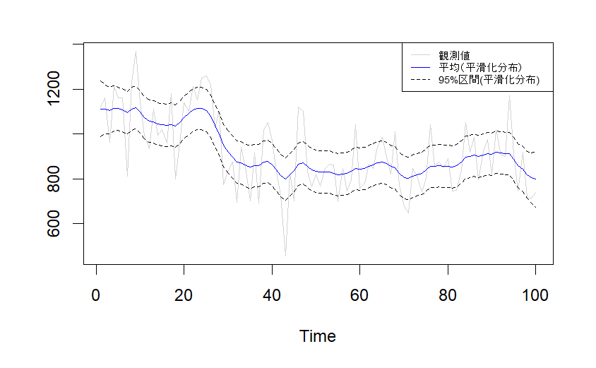

```r
trust_upper97.5 <- qnorm(p=0.975, mean=s, sd=sqrt(S))
trust_lower97.5 <- qnorm(p=0.025, mean=s, sd=sqrt(S))
ts.plot(cbind(as.vector(y),s,trust_upper97.5,trust_lower97.5),
        lty = c("solid","solid","dashed","dashed"),
        col = c("lightgray", "blue","black","black"),
        ylab = "")
legend(legend = c("観測値","平均（平滑化分布）","95%区間(平滑化分布)"),
       lty = c("solid","solid","dashed"),
       col = c("lightgray","blue","black"),
       x = "topright", text.width = 25, cex=0.6)
```

8.2 dlmパッケージを利用した、ローカルレベルモデルの実装

前処理

```r
library(dlm)
```

状態空間モデルの設定 1次元のローカルレベルモデルを設定

```r
mod <- dlmModPoly(order = 1)
```

内容を確認  
m0:事前分布の平均  
C0：事前分布の分散  
FF：観測行列  
V:観測ノイズの分散  
GG：状態遷移行列  
W：状態ノイズの分散  
Jで始まるパラメータ：時変のモデルで使用されるパラメータ

```r
str(mod)
```

```
List of 10
 $ m0 : num 0
 $ C0 : num [1, 1] 1e+07
 $ FF : num [1, 1] 1
 $ V  : num [1, 1] 1
 $ GG : num [1, 1] 1
 $ W  : num [1, 1] 1
 $ JFF: NULL
 $ JV : NULL
 $ JGG: NULL
 $ JW : NULL
 - attr(*, "class")= chr "dlm"
```

まずは、W,Vを最尤法で推定する。

```r
build_dlm <- function(par){
  mod$W[1,1] <- exp(par[1])
  mod$V[1,1] <- exp(par[2])
  return(mod)
}
```

最尤推定（初期値を変えて3回推定）

```r
lapply(list(c(0,0), c(1,10), c(20,3)),function(parms){
  dlmMLE(y=Nile, parm = parms, build = build_dlm)
})
```

```
[[1]]
[[1]]$par
[1] 7.291951 9.622437

[[1]]$value
[1] 549.6918

[[1]]$counts
function gradient
      34       34

[[1]]$convergence
[1] 0

[[1]]$message
[1] "CONVERGENCE: REL_REDUCTION_OF_F <= FACTR*EPSMCH"


[[2]]
[[2]]$par
[1] 7.291992 9.622452

[[2]]$value
[1] 549.6918

[[2]]$counts
function gradient
      22       22

[[2]]$convergence
[1] 0

[[2]]$message
[1] "CONVERGENCE: REL_REDUCTION_OF_F <= FACTR*EPSMCH"


[[3]]
[[3]]$par
[1] 7.291948 9.622437

[[3]]$value
[1] 549.6918

[[3]]$counts
function gradient
      40       40

[[3]]$convergence
[1] 0

[[3]]$message
[1] "CONVERGENCE: REL_REDUCTION_OF_F <= FACTR*EPSMCH"
```

パラメータの最尤推定（ヘッセ行列を戻り値に含める）

```r
fit_dlm <- dlmMLE(y=Nile, parm = c(0,0), build = build_dlm, hessian = TRUE)
```

デルタ法により最尤推定の漸近的な標準誤差を求める

```r
exp(fit_dlm$par) * sqrt(diag(solve(fit_dlm$hessian)))
```

```
[1] 1280.170 3145.999
```

パラメータの最尤推定結果をモデルに設定

```r
mod <- build_dlm(fit_dlm$par)
str(mod)
```

```
List of 10
 $ m0 : num 0
 $ C0 : num [1, 1] 1e+07
 $ FF : num [1, 1] 1
 $ V  : num [1, 1] 15100
 $ GG : num [1, 1] 1
 $ W  : num [1, 1] 1468
 $ JFF: NULL
 $ JV : NULL
 $ JGG: NULL
 $ JW : NULL
 - attr(*, "class")= chr "dlm"
```

フィルタリングの実施

```r
dlmfiltered_obj <- dlmFilter(y = Nile, mod = mod)
str(dlmfiltered_obj,max.level = 1)
```

```
List of 9
 $ y  : Time-Series [1:100] from 1871 to 1970: 1120 1160 963 1210 1160 1160 813 1230 1370 1140 ...
 $ mod:List of 10
  ..- attr(*, "class")= chr "dlm"
 $ m  : Time-Series [1:101] from 1870 to 1970: 0 1118 1140 1072 1117 ...
 $ U.C:List of 101
 $ D.C: num [1:101, 1] 3162.3 122.8 88.9 76 70 ...
 $ a  : Time-Series [1:100] from 1871 to 1970: 0 1118 1140 1072 1117 ...
 $ U.R:List of 100
 $ D.R: num [1:100, 1] 3162.5 128.6 96.8 85.1 79.8 ...
 $ f  : Time-Series [1:100] from 1871 to 1970: 0 1118 1140 1072 1117 ...
 - attr(*, "class")= chr "dlmFiltered"
```

フィルタリング分布の平均と分散を求める

```r
m <- dropFirst(dlmfiltered_obj$m)
m_stdev <- sqrt(
  dropFirst(as.numeric(
    dlmSvd2var(dlmfiltered_obj$U.C, dlmfiltered_obj$D.C)
  ))
)
```

信頼区間の計算

```r
m_quant <- list(m + qnorm(0.025,sd=m_stdev),m + qnorm(0.975, sd = m_stdev))
```

プロット

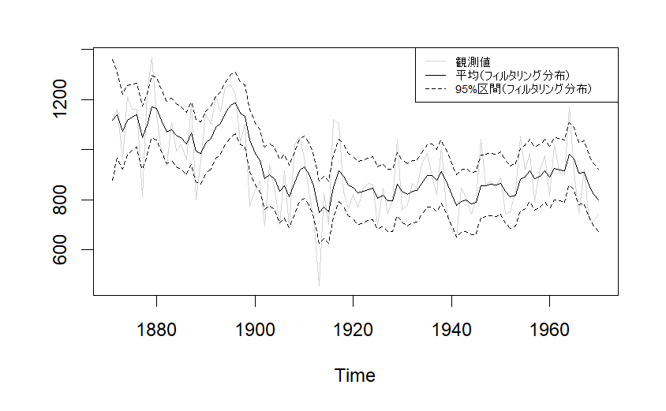

```r
ts.plot(cbind(Nile,m,do.call("cbind",m_quant)),
        col = c("lightgray","black","black", "black"),
        lty = c("solid","solid","dashed","dashed"))

legend(legend = c("観測値","平均（フィルタリング分布）","95%区間（フィルタリング分布）"),
       lty = c("solid","solid","dashed"),
       col = c("lightgray","black","black"),
       x = "topright", text.width = 32, cex=0.6)
```

カルマン予測

```r
dlmForecasted_obj <- dlmForecast(mod = dlmfiltered_obj, nAhead = 10)
```

結果確認

```r
str(dlmForecasted_obj, max.level = 1)
```

```
List of 4
 $ a: Time-Series [1:10, 1] from 1971 to 1980: 798 798 798 798 798 ...
  ..- attr(*, "dimnames")=List of 2
 $ R:List of 10
 $ f: Time-Series [1:10, 1] from 1971 to 1980: 798 798 798 798 798 ...
  ..- attr(*, "dimnames")=List of 2
 $ Q:List of 10
```

予測分布の平均と標準偏差を求める

```r
a <- ts(data=dlmForecasted_obj$a, start = c(1971,1))
a_sdev <- sqrt(
  as.numeric(dlmForecasted_obj$R)
)
```

信頼区間の計算

```r
a_quant <- list(a + qnorm(0.025,sd = a_sdev), a + qnorm(0.975,sd = a_sdev))
```

プロット

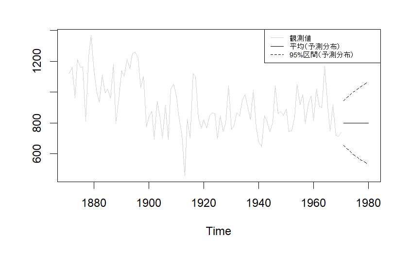

```r
ts.plot(cbind(Nile,a,do.call("cbind",a_quant)),
        col = c("lightgray","black","black", "black"),
        lty = c("solid","solid","dashed","dashed"))

legend(legend = c("観測値","平均（予測分布）","95%区間（予測分布）"),
       lty = c("solid","solid","dashed"),
       col = c("lightgray","black","black"),
       x = "topright", text.width = 32, cex=0.6)
```